# Project 2: Monte Carlo Simulation

## APMA 3100 Probability

### Part 2

#### Code and Output

```
Mean:  37.44362640429728 	First Quartile: 15.1029 	Median: 31.1324 	Third Quartile: 53.0852
F(15) = 0.2450
F(20) = 0.3270
F(20) = 0.3270
1 - F(40) = 0.3800
1 - F(65) = 0.1670
1 - F(90) = 0.0480
1 - F(100) = 0.0200
```

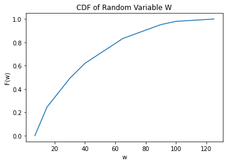

```python
import math
import matplotlib.pyplot as plt
# From https://en.wikipedia.org/wiki/Inverse_transform_sampling
# F^-1(r), where r is continous uniform random variable (0,1)
# and F^-1 = -1/lambda * ln(1-r)
def exponential(r):
    output = (-12*math.log(1-r))
    return output

def randomGen():
    seed = 1000
    a = 24693
    c = 1753
    K = 32768
    while True:
        seed = (((a * seed) + c) % K) # update seed
        output = seed / K             # return the random number
        yield output

# Monte Carlo Simulation
rand = randomGen()
def Monte_Carlo_sim(n):
    times=[] # list to hold the times for each simulation.

    # Run the simulation
    for i in range(n):
        times.append(callSim())

    # Calculate Stats
    mean = 0
    for x in times:
        mean += x

    times.sort()
    print("Mean: ", mean/n, "\tFirst Quartile: %3.4f" %times[249], "\tMedian: %3.4f" %times[499], "\tThird Quartile: %3.4f" %times[749])


    #Calculate Probabilities
    p15 = searchList(times, 15)/1000
    p20 = searchList(times, 20)/1000
    p30 = searchList(times, 30)/1000
    p40 = 1 - searchList(times, 40)/1000
    p65 = 1 - searchList(times, 65)/1000
    p90 = 1 - searchList(times, 90)/1000
    p100 = 1 - searchList(times, 100)/1000
    print("F(15) = %3.4f" %p15, "\nF(20) = %3.4f" %p20, "\nF(20) = %3.4f" %p20)
    print("1 - F(40) = %3.4f" %p40, "\n1 - F(65) = %3.4f" %p65, "\n1 - F(90) = %3.4f" %p90, "\n1 - F(100) = %3.4f" %p100)
    print()

    # Print Graph of CDF of W
    plt.plot([7, 15, 20, 30, 40, 65, 90, 100, 125], [0, p15, p20, p30, (1-p40), (1-p65),(1-p90), (1-p100), 1])
    plt.xlabel("w")
    plt.ylabel("F(w)")
    plt.title("CDF of Random Variable W")
    plt.show()

# The individual simulation of each call
def callSim():
    call=0
    time=0
    while(call < 4):

        if(next(rand) >= 0.5): # Caller Pick ups with 50% prob.
            time+=6 # time to turn on phone and call number
            time+= exponential(next(rand))
            # End Call - add values
            time+=1
            call+=1
            break # we have a completed call, break out of loop.

        else:
            time+=6

            if(next(rand) >= 0.4): # no pick up
                time+=20

            else:  # busy
                time+= 5

            # End Call - add values
            time+=1
            call+=1

    # When call >= 4 or we got a pickup
    #print(time)
    return time

# linear search used to find first occurance of a value greater than x. This will give us the
# index of the value that is approximately = F_W(w)
def searchList(list, x):
    for i in range(len(list)):
        if list[i] > x:
            return i

    return -1 #used for error catching.




Monte_Carlo_sim(1000)
```

# Analysis

### Sample Space

The sample space could have been deduced before the simulation, and has been confirmed afterwords. With us having the callee pickup the phone on the first try and time to pick up the phone approaching the limit of zero, we would have our lower at seven seconds. While for our upper bonds, because our exponential distribution has the range of $(0,\infty)$, our upper limit is also infinity. Therefore the Sample Space is $ S = { w \ge 7 } $

### Graph of the CDF of W

The above graph will update based on the number of simulations or a new random number generator.

### Is W a true exponential variable

No, for the following reasons:

1. The domain of W is $(7,\infty)$. However the domain of an exponential variable is $[0,\infty)$.
2. The exponential function is required to be memoryless, however our model has memory as a key function. The memory of how many calls have been made.
3. If we take the quartile function, we arrive at a $\lambda = \frac{1}{52.499}$ from the calculation of our first quartile value. If we use this $\lambda$ value for our median and third quartile, we have the following.

$$Median = 52.499\cdot ln(2) = 36.389$$

$$Third \ Quartile = 52.599 \cdot ln(4) = 72.778$$

From this, we can see, the distribution does not follow the exponential distribution.

# Reflection

### Which step was the most/least challenging?

The most challenging part was trying to understand how to create the inverse transform of $Fx(x)$. This was because I had no memory of this from class or previous calculus classes. I tried to derive this naively and ended up with an answer that was slightly off from the actual answer. I then started looking through wikipedia for the correct article and found one that described the purpose and implementation of this transformation.

### Which step was the most/least time consuming?

The least time consuming part was the writing of the simulation function. I had designed the logic and data flow well in part one of the project, and so implementing it was actually easy. I had already implemented the entire simulation with a place holder for the exponential function when I understood what equation I should use. However, since I am so new with python, there was alot of searching for how to do things I know how to do in other programming languages.

### How certain are you that your results are without error?

I am confident that the majority of my results are correct. The fast that my domain is correct has given me hope. However, I still do not truly understand the inverse transformation of exponential distribution. I did a rough expected value on the five possible outcomes, and had $E[W] = 37.5$ which is actuall close to my actual mean. This gives me some confidence that my answer is correct. The other figures are less so. I used a naive approach for calculating the CDF values. In which I wrote a linear search function to find the first index that is greater than argument. This would give me a close approximation of the correct value. Overall my $P[GRADE \ge 0.90] = 0.7$.

### How to improve the simulation?

The most realistic improvement would be to factor in time and day of week for the callee to change the probability of the three possible outcomes. As we all know, people answer phone calls in context of the daily routine. I notice, that I receive the majority of my robo calls from 9:00 - 13:00 EST, which I assume is because people are at work and typically expected to pick up the phone.